# Trend Analysis for Maximum and Minimum Temperature at Utah (USA) Ski Resorts

Hadia Akbar, Emily Wilkins

May 1, 2021

This document provides a trend analysis for maximum and minimum temperature for Utah (USA) ski resorts from 1980 - 2019. The script downloads data from Daymet for each resort, takes average for max and min temperature for each resort by resort ski season,and plots the trend for each resort for max and min temperature. It also runs a Mann-Kendall Trend test with Sen's slope to determine the temperature trend over time.

### Load the libraries that will be required for this analysis.

```r
library(readr)            # to read csv files for resort detaoils
library(daymetr)          # to get weather data of points
library(tidyverse)        # for cleaning data
library(lubridate)        # for managing dates and conversions
library(ggplot2)          # for plotting
library(trend)            # for Mann-Kendall Trend test and Sen's slope
```

# 1- Data Download

First we download data from Daymet. Daymet provides modeled daily weather data for North America on a 1 km grid from 1980 - the previous year. Information about Daymet is available [here](https://daymet.ornl.gov/overview).

We need coordinates of each resort to download data in proper format. We have placed the required file to download data from daymet for this analysis in a hydroshare repository that can be accessed by the following lines

```r
##Download resort data from hydroshare
file <- "resort_coords.csv"
url <- "https://www.hydroshare.org/resource/a1c6c9300f63482a95634996fa971454/data/contents/DataDownload/Historic/resort_coords.csv"
##Downlaod file in the working directory
if (!file.exists(file)){
  download.file(url, file)}
# Reading in a file with all the ski resort coordinates
coord <- read_csv("resort_coords.csv")
```

Use the coord file to downlaod data from Daymet.

```r
#Function to download Daymet data for each point in a CSV file by year
raw_weather_data <- download_daymet_batch(
  file_location = "resort_coords.csv",
  start = 1980, end = 2019,
  internal = TRUE, # if T, it saves to workspace
  simplify = TRUE) # if T, outputs tidy data (tibble)
```

# 2- Clean up and organize data

We have a messy data frame with weather variables for each point at every day between the years specified. We will extract and tidy up the data.

```r
# Filters to only keep tmax and tmin
weather_data <- raw_weather_data %>% filter(measurement %in% c("tmax..deg.c.", "tmin..deg.c."))

# Reshaping data so that each weather variable is it's own column
weather_data <- spread(weather_data, measurement, value)

#Create a date column , create date from yday and year
weather_data <- weather_data %>%
  mutate(date = as.Date(paste(year, yday, sep = "-"), "%Y-%j"))

#Rename columns with intuitive names
colnames(weather_data)[8] <- "Tmax"
colnames(weather_data)[9] <- "Tmin"
```

# 3 - Summarize the data for each ski resort by ski season.

We need to read in the file with the opening and closing dates of each resort which is also placed in the hydroshare repository.

```r
## Download and save the file containing opening and closing dates for each resort.
file2 <- "Season.csv"
url2 <-  "https://www.hydroshare.org/resource/a1c6c9300f63482a95634996fa971454/data/contents/DataDownload/Historic/Season.csv"

if (!file.exists(file2)){
  download.file(url2, file2)
}

#Read the downloaded file
Resort <- read.csv("Season.csv")

#Convert factors to dates and add columns with yday (day of the year) to the "resort" dataset.
Resort <- Resort %>%
  mutate(Opening = as.Date(Resort$Opening_longest, "%m/%d/%y"),
         Closing = as.Date(Resort$Closing_longest, "%m/%d/%y"))
Resort <- Resort %>%
  mutate(Opening_yday =  yday(Resort$Opening),
         Closing_yday = yday(Resort$Closing))

#In this step we will create a clean data set with max and min temp for each resort according to opening and closing day of each resort

#Create a placeholder for the data set
resort_data <-NULL

#This loops through each resort and makes a dataset for that resort, then combines together
for (i in 1:nrow(Resort)) {
  resort <- as.character(Resort[i,1])  #choose resort
  open <- as.numeric(Resort[i,"Opening_yday"])      #opening date
  close <- as.numeric(Resort[i,"Closing_yday"])     #closing date
  #Filters the big database to only have data from this resort
  r <- weather_data %>% dplyr::filter(site == resort) # %>% mutate(date_noyear = format(date, format="%m-%d"))
  #Now filter this to only keep dates when the resort is open using open and close date
  r <- r %>% dplyr::filter(yday >= open | yday <= close) %>%
    select(site, date, Tmax, Tmin, yday)
  #Fills the empty data frame first and combines the individual datasets created in each loop.
resort_data <- rbind(r, resort_data)
}
```

Now we aggregate and summarize daily values by ski resort season.

```r
#create a placeholder for the cleaned and summarized dataset
data <- NULL
#This section loops through the dataset and create summary (mean) by each resort
for (i in 1:nrow(Resort)) {

  resort <- as.character(Resort[i,1])
  #Opening and closing date of resort, we will use this to create ski season
  open <- as.Date(Resort[i,"Opening"])
  close <- as.Date(Resort[i,"Closing"])

  offset <- Resort[[i,"Opening_yday"]]
  d <- resort_data %>%
  filter(site == resort)%>%
    mutate(year = lubridate::year(date)) %>%
    mutate(SkiSeason = case_when(yday <= 210 ~ (year - 1), yday >= 211 ~ year)) %>% # So Nov - April appears in one year
    group_by(site, SkiSeason) %>% # Group by resort and ski season
    summarise(
      start_date = min(date), end_date = max(date),
      mean_tmax=mean(Tmax), mean_tmin=mean(Tmin), n_days = n(),
      days_less_5c = sum(Tmin <= -5),
      proportion_less_5c = days_less_5c / n_days)%>%
    filter(SkiSeason >= 1980, SkiSeason <= 2018)
  data <- rbind(d, data)
}
```

# 4 - Plots

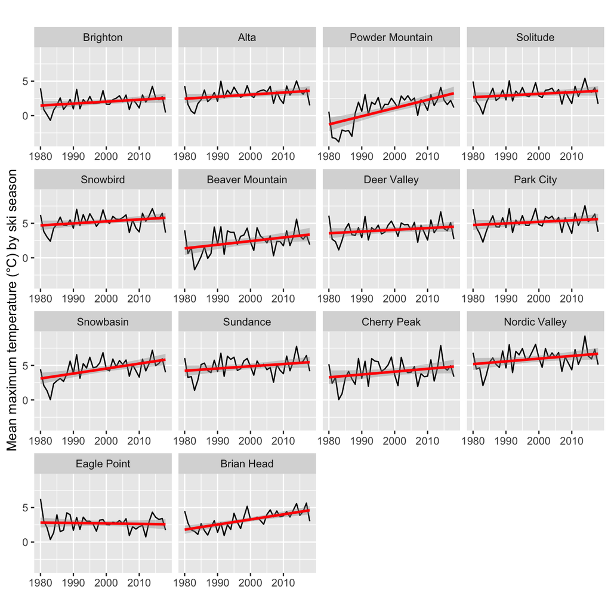

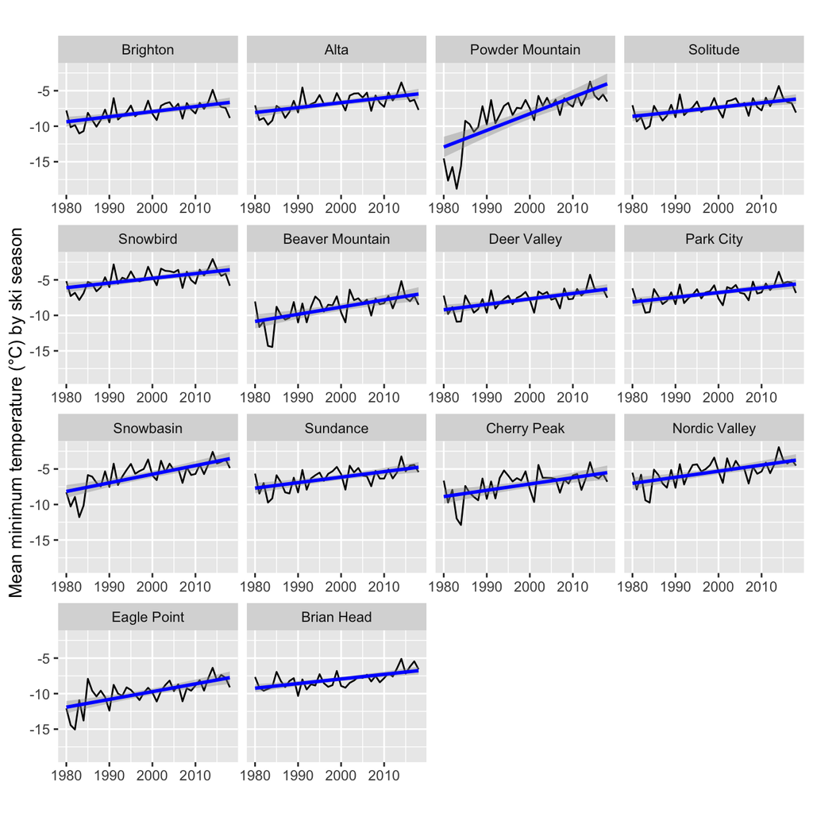

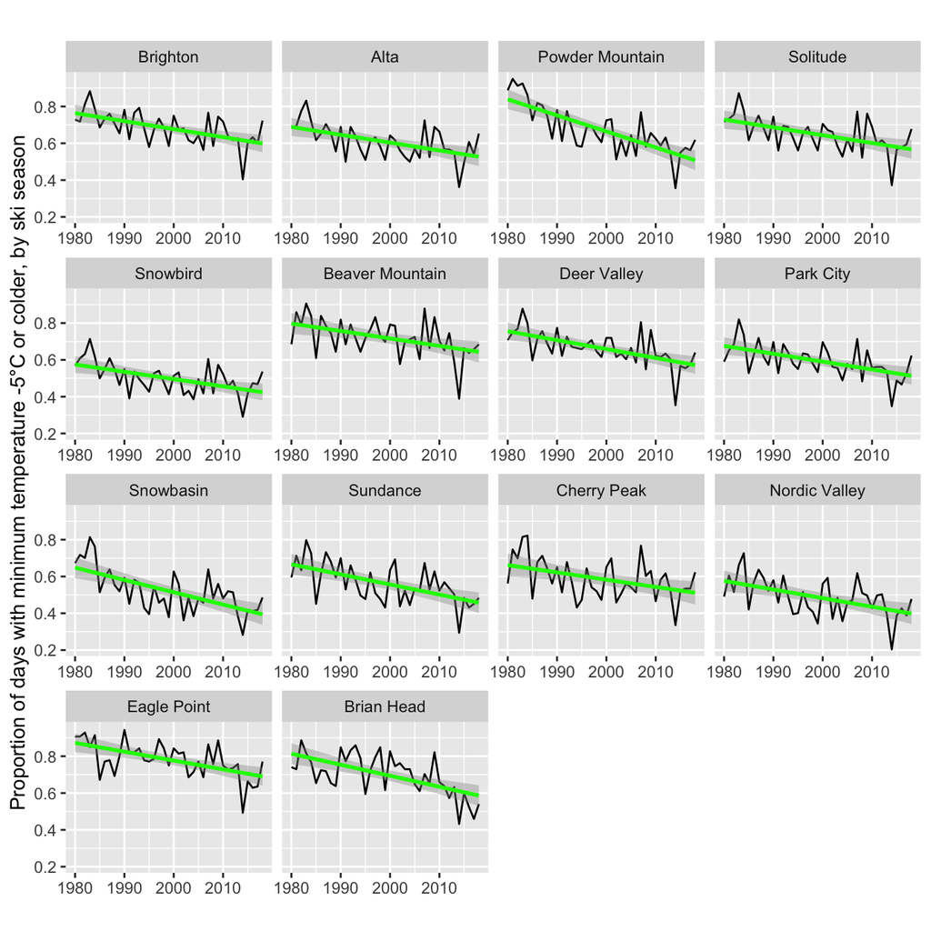

# 5- Mann-Kendall Trend analysis with Sen's Slope

Here we run Mann-Kendall Trend and Sen's Slope for each resort to see the general trend in maximum temperature, minimum temperature, and the proportion of the season with minimum temperatures -5 C or below from 1980 - 2018. These are to get a sense of the general trend; there is high year-to-year variability in any weather data. Regressions each have n = 39 (one data point per season, 1980 - 2018).

```r
# Setting up an empty table to record results
table1 <- matrix(NA, nrow = 14, ncol = 10)
x <- c("metric", "resort", "z stat", "S", "S var", "tau", "p-value", "sen's slope", "95% CI, low", "95% CI, high")
colnames(table1) <- x
table1 <- as.data.frame(table1)
table1[,1:2] <- as.character(table1[,1:2])

# Reorder Resorts to match order in the paper
order <- c("Brighton", "Alta", "Powder Mountain", "Solitude", "Snowbird", "Beaver Mountain", "Deer Valley", "Park City", "Snowbasin", "Sundance", "Cherry Peak", "Nordic Valley", "Eagle Point", "Brian Head")
Resort <- Resort %>% slice(match(order, Site))

##### Max Temp M-K
for (i in 1:nrow(Resort)) {
  resort <- as.character(Resort[i,1])  #choose resort
  seasonal_data <- data %>% dplyr::filter(site == resort) #Filters the database to only have data from this resort
  maxtemp <- trend::mk.test(seasonal_data$mean_tmax, continuity = TRUE) # Runs Mann-Kendall trend test
  sen <- sens.slope(seasonal_data$mean_tmax, conf.level = 0.95)
  # Fill in the table
  table1[i,1] <- "Mean Seasonal Daily Max Temp"
  table1[i,2] <- resort
  table1[i,3] <- maxtemp$statistic # records z statistic
  table1[i,4] <- maxtemp$estimates[1] # records S
  table1[i,5] <- maxtemp$estimates[2] # records variance on S
  table1[i,6] <- maxtemp$estimates[3] # records tau
  table1[i,7] <- maxtemp$p.value # records p-value
  table1[i,8] <- sen$estimates # records Sen's slope
  table1[i,9] <- sen$conf.int[1] # records CI
  table1[i,10] <- sen$conf.int[2] # records CI
}

# Rounds everything to 3 decimals
table1[,3:10] <- round(table1[,3:10], 3)
table1
```

| metric | resort | z stat | S | S var | tau | p-value | sen's slope | 95% CI, low | 95% CI, high |
| --- | --- | --- | --- | --- | --- | --- | --- | --- | --- |
| Mean Seasonal Daily Max Temp | Brighton | 2.347 | 195 | 6833.667 | 0.263 | 0.019 | 0.036 | 0.007 | 0.062 |
| Mean Seasonal Daily Max Temp | Alta | 2.056 | 171 | 6833.667 | 0.231 | 0.040 | 0.039 | 0.001 | 0.066 |
| Mean Seasonal Daily Max Temp | Powder Mountain | 3.556 | 295 | 6833.667 | 0.398 | 0.000 | 0.101 | 0.042 | 0.151 |
| Mean Seasonal Daily Max Temp | Solitude | 1.597 | 133 | 6833.667 | 0.179 | 0.110 | 0.029 | -0.009 | 0.062 |
| Mean Seasonal Daily Max Temp | Snowbird | 1.935 | 161 | 6833.667 | 0.217 | 0.053 | 0.037 | 0.000 | 0.063 |
| Mean Seasonal Daily Max Temp | Beaver Mountain | 1.669 | 139 | 6833.667 | 0.188 | 0.095 | 0.048 | -0.009 | 0.094 |
| Mean Seasonal Daily Max Temp | Deer Valley | 1.403 | 117 | 6833.667 | 0.158 | 0.161 | 0.030 | -0.010 | 0.064 |
| Mean Seasonal Daily Max Temp | Park City | 1.403 | 117 | 6833.667 | 0.158 | 0.161 | 0.024 | -0.011 | 0.058 |
| Mean Seasonal Daily Max Temp | Snowbasin | 3.169 | 263 | 6833.667 | 0.355 | 0.002 | 0.069 | 0.027 | 0.113 |
| Mean Seasonal Daily Max Temp | Sundance | 1.403 | 117 | 6833.667 | 0.158 | 0.161 | 0.028 | -0.014 | 0.068 |

[output cut: 4 more lines]

```r
# Output table if desired
#write.csv(table1, "M_K_trends_maxtemp.csv", row.names = FALSE)

##### Min Temp M-K
for (i in 1:nrow(Resort)) {
  resort <- as.character(Resort[i,1])  #choose resort
  seasonal_data <- data %>% dplyr::filter(site == resort) #Filters the database to only have data from this resort
  mintemp <- trend::mk.test(seasonal_data$mean_tmin, continuity = TRUE) # Runs Mann-Kendall trend test
  sen <- sens.slope(seasonal_data$mean_tmin, conf.level = 0.95)
  # Fill in the table
  table1[i,1] <- "Mean Seasonal Daily Min Temp"
  table1[i,2] <- resort
  table1[i,3] <- mintemp$statistic # records z statistic
  table1[i,4] <- mintemp$estimates[1] # records S
  table1[i,5] <- mintemp$estimates[2] # records variance on S
  table1[i,6] <- mintemp$estimates[3] # records tau
  table1[i,7] <- mintemp$p.value # records p-value
  table1[i,8] <- sen$estimates # records Sen's slope
  table1[i,9] <- sen$conf.int[1] # records CI
  table1[i,10] <- sen$conf.int[2] # records CI
}

# Rounds everything to 3 decimals
table1[,3:10] <- round(table1[,3:10], 3)
table1
```

| metric | resort | z stat | S | S var | tau | p-value | sen's slope | 95% CI, low | 95% CI, high |
| --- | --- | --- | --- | --- | --- | --- | --- | --- | --- |
| Mean Seasonal Daily Min Temp | Brighton | 3.895 | 323 | 6833.667 | 0.436 | 0.000 | 0.075 | 0.037 | 0.111 |
| Mean Seasonal Daily Min Temp | Alta | 3.653 | 303 | 6833.667 | 0.409 | 0.000 | 0.072 | 0.032 | 0.113 |
| Mean Seasonal Daily Min Temp | Powder Mountain | 5.734 | 475 | 6833.667 | 0.641 | 0.000 | 0.167 | 0.116 | 0.243 |
| Mean Seasonal Daily Min Temp | Solitude | 3.484 | 289 | 6833.667 | 0.390 | 0.000 | 0.065 | 0.033 | 0.103 |
| Mean Seasonal Daily Min Temp | Snowbird | 3.556 | 295 | 6833.667 | 0.398 | 0.000 | 0.070 | 0.032 | 0.107 |
| Mean Seasonal Daily Min Temp | Beaver Mountain | 3.798 | 315 | 6833.667 | 0.425 | 0.000 | 0.085 | 0.036 | 0.133 |
| Mean Seasonal Daily Min Temp | Deer Valley | 4.137 | 343 | 6833.667 | 0.463 | 0.000 | 0.076 | 0.037 | 0.108 |
| Mean Seasonal Daily Min Temp | Park City | 3.774 | 313 | 6833.667 | 0.422 | 0.000 | 0.069 | 0.035 | 0.101 |
| Mean Seasonal Daily Min Temp | Snowbasin | 4.645 | 385 | 6833.667 | 0.520 | 0.000 | 0.106 | 0.068 | 0.150 |
| Mean Seasonal Daily Min Temp | Sundance | 3.859 | 320 | 6832.667 | 0.432 | 0.000 | 0.073 | 0.033 | 0.112 |

[output cut: 4 more lines]

```r
# Output table if desired
#write.csv(table1, "M_K_trends_mintemp.csv", row.names = FALSE)

##### Proportion of season -5C or below, M-K
for (i in 1:nrow(Resort)) {
  resort <- as.character(Resort[i,1])  #choose resort
  seasonal_data <- data %>% dplyr::filter(site == resort) #Filters the database to only have data from this resort
  prop5c <- trend::mk.test(seasonal_data$proportion_less_5c, continuity = TRUE) # Runs Mann-Kendall trend test
  sen <- sens.slope(seasonal_data$proportion_less_5c, conf.level = 0.95)
  # Fill in the table
  table1[i,1] <- "Proportion of Season -5C or below"
  table1[i,2] <- resort
  table1[i,3] <- prop5c$statistic # records z statistic
  table1[i,4] <- prop5c$estimates[1] # records S
  table1[i,5] <- prop5c$estimates[2] # records variance on S
  table1[i,6] <- prop5c$estimates[3] # records tau
  table1[i,7] <- prop5c$p.value # records p-value
  table1[i,8] <- sen$estimates # records Sen's slope
  table1[i,9] <- sen$conf.int[1] # records CI
  table1[i,10] <- sen$conf.int[2] # records CI
}

# Rounds everything to 3 decimals
table1[,3:10] <- round(table1[,3:10], 3)
table1
```

| metric | resort | z stat | S | S var | tau | p-value | sen's slope | 95% CI, low | 95% CI, high |
| --- | --- | --- | --- | --- | --- | --- | --- | --- | --- |
| Proportion of Season -5C or below | Brighton | -3.547 | -294 | 6824.667 | -0.399 | 0.000 | -0.004 | -0.007 | -0.002 |
| Proportion of Season -5C or below | Alta | -3.270 | -271 | 6816.333 | -0.369 | 0.001 | -0.004 | -0.006 | -0.002 |
| Proportion of Season -5C or below | Powder Mountain | -4.974 | -412 | 6826.667 | -0.559 | 0.000 | -0.009 | -0.011 | -0.006 |
| Proportion of Season -5C or below | Solitude | -3.366 | -279 | 6819.667 | -0.380 | 0.001 | -0.004 | -0.006 | -0.002 |
| Proportion of Season -5C or below | Snowbird | -3.403 | -282 | 6817.333 | -0.384 | 0.001 | -0.004 | -0.006 | -0.002 |
| Proportion of Season -5C or below | Beaver Mountain | -2.931 | -243 | 6818.333 | -0.331 | 0.003 | -0.004 | -0.006 | -0.001 |
| Proportion of Season -5C or below | Deer Valley | -4.056 | -336 | 6821.333 | -0.457 | 0.000 | -0.005 | -0.006 | -0.003 |
| Proportion of Season -5C or below | Park City | -3.452 | -286 | 6814.667 | -0.390 | 0.001 | -0.004 | -0.006 | -0.002 |
| Proportion of Season -5C or below | Snowbasin | -3.937 | -326 | 6816.000 | -0.444 | 0.000 | -0.007 | -0.009 | -0.004 |
| Proportion of Season -5C or below | Sundance | -3.547 | -294 | 6822.000 | -0.400 | 0.000 | -0.005 | -0.008 | -0.003 |

[output cut: 4 more lines]

```r
# Output table if desired
#write.csv(table1, "M_K_trends_prop5c.csv", row.names = FALSE)
```

# 6 - This part only looks at the temperatures from opening through the New Years Holiday (Jan 2)

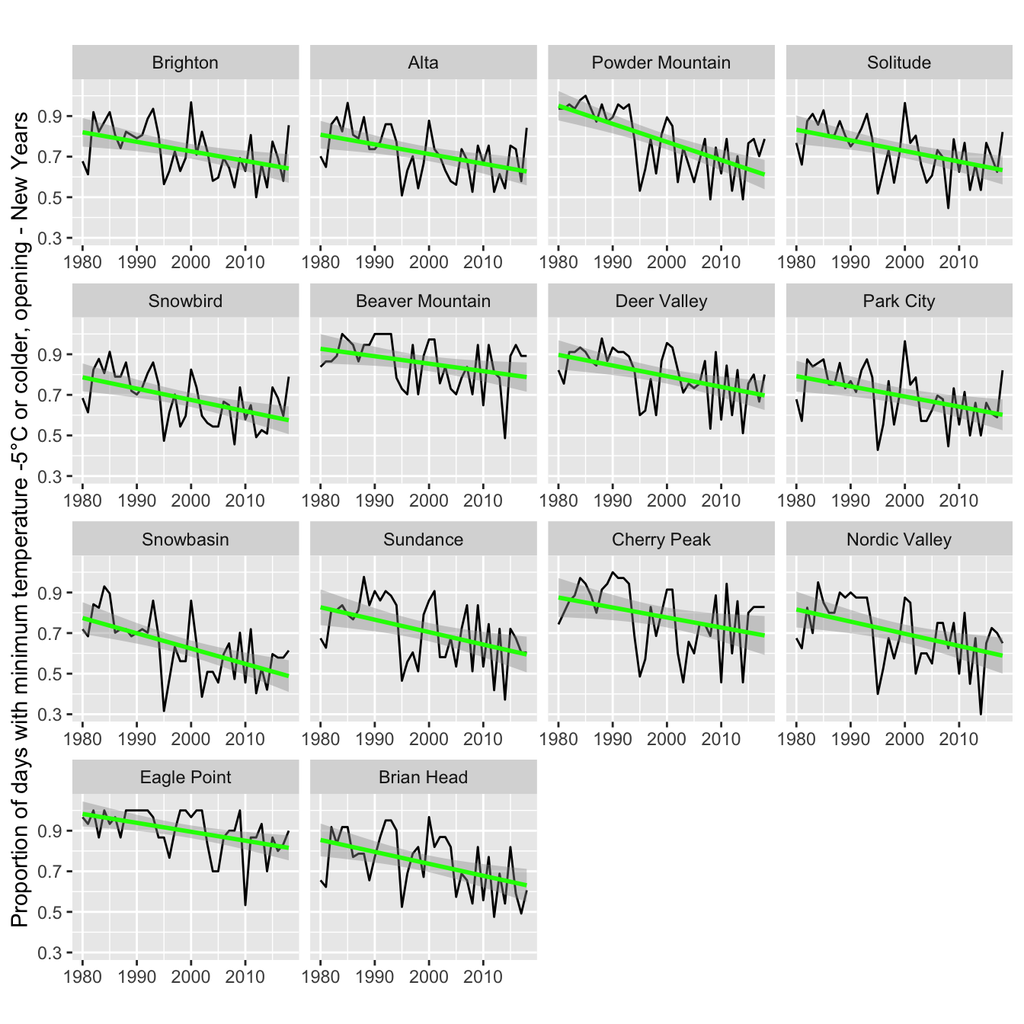

```r
#Create a placeholder for the data set
resort_data <-NULL
#This loops through each resort and makes a dataset for that resort, then combines together
for (i in 1:nrow(Resort)) {
  resort <- as.character(Resort[i,1])  #choose resort
  open <- as.numeric(Resort[i,"Opening_yday"])      #opening date
  close <- as.numeric(Resort[i,"Closing_yday"])     #closing date
  #Filters the big database to only have data from this resort
  r <- weather_data %>% dplyr::filter(site == resort) # %>% mutate(date_noyear = format(date, format="%m-%d"))
  #Now filter this to only keep dates when the resort is open using open and close date
  r <- r %>% dplyr::filter(yday >= open | yday <= 2) %>%
    select(site, date, Tmax, Tmin, yday)
  #Fills the empty data frame first and combines the individual datasets created in each loop.
resort_data <- rbind(r, resort_data)
}

#create a placeholder for the cleaned and summarized dataset
data <- NULL
#This section loops through the dataset and create summary (mean) by each resort
for (i in 1:nrow(Resort)) {
  resort <- as.character(Resort[i,1])
  #Opening and closing date of resort, we will use this to create ski season
  open <- as.Date(Resort[i,"Opening"])
  close <- as.Date(Resort[i,"Closing"])

  offset <- Resort[[i,"Opening_yday"]]
  d <- resort_data %>%
  filter(site == resort)%>%
    mutate(year = lubridate::year(date)) %>%
    mutate(SkiSeason = case_when(yday <= 210 ~ (year - 1), yday >= 211 ~ year)) %>% # Offset so Nov - April appear in same season/year
    group_by(site, SkiSeason) %>% #Group by ski season and resort
    summarise(
      start_date = min(date), end_date = max(date),
      mean_tmax=mean(Tmax), mean_tmin=mean(Tmin), n_days = n(),
      days_less_5c = sum(Tmin <= -5),
      proportion_less_5c = days_less_5c / n_days)%>%
    filter(SkiSeason >= 1980, SkiSeason <= 2018)
  data <- rbind(d, data)
}

# Figure for proportion with snowmaking
d2 <- data %>% mutate(site2 = site)
d2$site2 <- as.factor(d2$site2)
d2$site2 <- fct_relevel(d2$site2, levels = c("Brighton", "Alta", "Powder Mountain", "Solitude", "Snowbird", "Beaver Mountain", "Deer Valley", "Park City", "Snowbasin", "Sundance", "Cherry Peak", "Nordic Valley", "Eagle Point", "Brian Head"))

c<- ggplot()+
  geom_line(data=d2, aes(x=SkiSeason, y = proportion_less_5c), color = "black") +
  geom_smooth(data=d2, aes(SkiSeason, proportion_less_5c), method="lm", color ="green") +
  labs(title= " ", y = "Proportion of days with minimum temperature -5°C or colder, opening - New Years", x = "") +
  theme(plot.title = element_text(hjust = 0.5, size=12)) +
  xlim(1980, 2018) +
  facet_wrap( ~ site2,
              scales = "free_x") # if removed, x ticks don't show in all plots
c
```

```r
# Uncomment if you want to save the figure
#ggsave("Trend_T_5_EarlySeason_ordered.tiff", plot= c , height=7 , width=7 , units= "in", dpi= 600)

# Setting up an empty table to record results
table1 <- matrix(NA, nrow = 14, ncol = 10)
x <- c("metric", "resort", "z stat", "S", "S var", "tau", "p-value", "sen's slope", "95% CI, low", "95% CI, high")
colnames(table1) <- x
table1 <- as.data.frame(table1)
table1[,1:2] <- as.character(table1[,1:2])

##### Max Temp M-K
for (i in 1:nrow(Resort)) {
  resort <- as.character(Resort[i,1])  #choose resort
  seasonal_data <- data %>% dplyr::filter(site == resort) #Filters the database to only have data from this resort
  maxtemp <- trend::mk.test(seasonal_data$mean_tmax, continuity = TRUE) # Runs Mann-Kendall trend test
  sen <- sens.slope(seasonal_data$mean_tmax, conf.level = 0.95)
  # Fill in the table
  table1[i,1] <- "Mean Seasonal Daily Max Temp (Early season)"
  table1[i,2] <- resort
  table1[i,3] <- maxtemp$statistic # records z statistic
  table1[i,4] <- maxtemp$estimates[1] # records S
  table1[i,5] <- maxtemp$estimates[2] # records variance on S
  table1[i,6] <- maxtemp$estimates[3] # records tau
  table1[i,7] <- maxtemp$p.value # records p-value
  table1[i,8] <- sen$estimates # records Sen's slope
  table1[i,9] <- sen$conf.int[1] # records CI
  table1[i,10] <- sen$conf.int[2] # records CI
}

# Rounds everything to 3 decimals
table1[,3:10] <- round(table1[,3:10], 3)
table1
```

| metric | resort | z stat | S | S var | tau | p-value | sen's slope | 95% CI, low | 95% CI, high |
| --- | --- | --- | --- | --- | --- | --- | --- | --- | --- |
| Mean Seasonal Daily Max Temp (Early season) | Brighton | 2.177 | 181 | 6833.667 | 0.244 | 0.029 | 0.052 | 0.003 | 0.092 |
| Mean Seasonal Daily Max Temp (Early season) | Alta | 1.984 | 165 | 6833.667 | 0.223 | 0.047 | 0.043 | 0.000 | 0.092 |
| Mean Seasonal Daily Max Temp (Early season) | Powder Mountain | 4.452 | 369 | 6833.667 | 0.498 | 0.000 | 0.134 | 0.079 | 0.199 |
| Mean Seasonal Daily Max Temp (Early season) | Solitude | 1.294 | 108 | 6832.667 | 0.146 | 0.196 | 0.039 | -0.008 | 0.084 |
| Mean Seasonal Daily Max Temp (Early season) | Snowbird | 2.008 | 167 | 6833.667 | 0.225 | 0.045 | 0.038 | 0.002 | 0.088 |
| Mean Seasonal Daily Max Temp (Early season) | Beaver Mountain | 1.476 | 123 | 6833.667 | 0.166 | 0.140 | 0.046 | -0.011 | 0.109 |
| Mean Seasonal Daily Max Temp (Early season) | Deer Valley | 1.185 | 99 | 6833.667 | 0.134 | 0.236 | 0.032 | -0.028 | 0.088 |
| Mean Seasonal Daily Max Temp (Early season) | Park City | 1.258 | 105 | 6833.667 | 0.142 | 0.208 | 0.043 | -0.017 | 0.085 |
| Mean Seasonal Daily Max Temp (Early season) | Snowbasin | 3.315 | 275 | 6833.667 | 0.371 | 0.001 | 0.084 | 0.036 | 0.134 |
| Mean Seasonal Daily Max Temp (Early season) | Sundance | 1.137 | 95 | 6833.667 | 0.128 | 0.255 | 0.030 | -0.026 | 0.081 |

[output cut: 4 more lines]

```r
# Output table if desired
#write.csv(table1, "M_K_trends_maxtemp_EarlySeason.csv", row.names = FALSE)

##### Min Temp M-K
for (i in 1:nrow(Resort)) {
  resort <- as.character(Resort[i,1])  #choose resort
  seasonal_data <- data %>% dplyr::filter(site == resort) #Filters the database to only have data from this resort
  mintemp <- trend::mk.test(seasonal_data$mean_tmin, continuity = TRUE) # Runs Mann-Kendall trend test
  sen <- sens.slope(seasonal_data$mean_tmin, conf.level = 0.95)
  # Fill in the table
  table1[i,1] <- "Mean Seasonal Daily Min Temp (Early season)"
  table1[i,2] <- resort
  table1[i,3] <- mintemp$statistic # records z statistic
  table1[i,4] <- mintemp$estimates[1] # records S
  table1[i,5] <- mintemp$estimates[2] # records variance on S
  table1[i,6] <- mintemp$estimates[3] # records tau
  table1[i,7] <- mintemp$p.value # records p-value
  table1[i,8] <- sen$estimates # records Sen's slope
  table1[i,9] <- sen$conf.int[1] # records CI
  table1[i,10] <- sen$conf.int[2] # records CI
}

# Rounds everything to 3 decimals
table1[,3:10] <- round(table1[,3:10], 3)
table1
```

| metric | resort | z stat | S | S var | tau | p-value | sen's slope | 95% CI, low | 95% CI, high |
| --- | --- | --- | --- | --- | --- | --- | --- | --- | --- |
| Mean Seasonal Daily Min Temp (Early season) | Brighton | 3.629 | 301 | 6833.667 | 0.406 | 0.000 | 0.078 | 0.031 | 0.118 |
| Mean Seasonal Daily Min Temp (Early season) | Alta | 3.242 | 269 | 6833.667 | 0.363 | 0.001 | 0.074 | 0.030 | 0.115 |
| Mean Seasonal Daily Min Temp (Early season) | Powder Mountain | 4.863 | 403 | 6833.667 | 0.544 | 0.000 | 0.210 | 0.133 | 0.277 |
| Mean Seasonal Daily Min Temp (Early season) | Solitude | 3.266 | 271 | 6833.667 | 0.366 | 0.001 | 0.068 | 0.024 | 0.111 |
| Mean Seasonal Daily Min Temp (Early season) | Snowbird | 3.145 | 261 | 6833.667 | 0.352 | 0.002 | 0.068 | 0.027 | 0.111 |
| Mean Seasonal Daily Min Temp (Early season) | Beaver Mountain | 2.613 | 217 | 6833.667 | 0.293 | 0.009 | 0.089 | 0.022 | 0.160 |
| Mean Seasonal Daily Min Temp (Early season) | Deer Valley | 2.927 | 243 | 6833.667 | 0.328 | 0.003 | 0.076 | 0.026 | 0.123 |
| Mean Seasonal Daily Min Temp (Early season) | Park City | 2.589 | 215 | 6833.667 | 0.290 | 0.010 | 0.065 | 0.017 | 0.111 |
| Mean Seasonal Daily Min Temp (Early season) | Snowbasin | 4.161 | 345 | 6833.667 | 0.466 | 0.000 | 0.114 | 0.073 | 0.164 |
| Mean Seasonal Daily Min Temp (Early season) | Sundance | 2.637 | 219 | 6833.667 | 0.296 | 0.008 | 0.057 | 0.013 | 0.112 |

[output cut: 4 more lines]

```r
# Output table if desired
# write.csv(table1, "M_K_trends_mintemp_EarlySeason.csv", row.names = FALSE)

##### Proportion of season snowmaking, M-K
for (i in 1:nrow(Resort)) {
  resort <- as.character(Resort[i,1])  #choose resort
  seasonal_data <- data %>% dplyr::filter(site == resort) #Filters the database to only have data from this resort
  prop5c <- trend::mk.test(seasonal_data$proportion_less_5c, continuity = TRUE) # Runs Mann-Kendall trend test
  sen <- sens.slope(seasonal_data$proportion_less_5c, conf.level = 0.95)
  # Fill in the table
  table1[i,1] <- "Proportion of Season -5C or below (Early Season)"
  table1[i,2] <- resort
  table1[i,3] <- prop5c$statistic # records z statistic
  table1[i,4] <- prop5c$estimates[1] # records S
  table1[i,5] <- prop5c$estimates[2] # records variance on S
  table1[i,6] <- prop5c$estimates[3] # records tau
  table1[i,7] <- prop5c$p.value # records p-value
  table1[i,8] <- sen$estimates # records Sen's slope
  table1[i,9] <- sen$conf.int[1] # records CI
  table1[i,10] <- sen$conf.int[2] # records CI
}

# Rounds everything to 3 decimals
table1[,3:10] <- round(table1[,3:10], 3)
table1
```

| metric | resort | z stat | S | S var | tau | p-value | sen's slope | 95% CI, low | 95% CI, high |
| --- | --- | --- | --- | --- | --- | --- | --- | --- | --- |
| Proportion of Season -5C or below (Early Season) | Brighton | -2.741 | -227 | 6797.000 | -0.312 | 0.006 | -0.005 | -0.009 | -0.002 |
| Proportion of Season -5C or below (Early Season) | Alta | -2.789 | -231 | 6799.000 | -0.317 | 0.005 | -0.005 | -0.009 | -0.002 |
| Proportion of Season -5C or below (Early Season) | Powder Mountain | -4.314 | -356 | 6772.000 | -0.494 | 0.000 | -0.008 | -0.012 | -0.005 |
| Proportion of Season -5C or below (Early Season) | Solitude | -3.092 | -256 | 6799.333 | -0.352 | 0.002 | -0.005 | -0.009 | -0.002 |
| Proportion of Season -5C or below (Early Season) | Snowbird | -3.248 | -269 | 6807.000 | -0.369 | 0.001 | -0.006 | -0.010 | -0.003 |
| Proportion of Season -5C or below (Early Season) | Beaver Mountain | -1.853 | -153 | 6731.667 | -0.215 | 0.064 | -0.003 | -0.006 | 0.000 |
| Proportion of Season -5C or below (Early Season) | Deer Valley | -3.051 | -252 | 6770.000 | -0.350 | 0.002 | -0.005 | -0.008 | -0.002 |
| Proportion of Season -5C or below (Early Season) | Park City | -2.860 | -237 | 6809.000 | -0.325 | 0.004 | -0.006 | -0.009 | -0.002 |
| Proportion of Season -5C or below (Early Season) | Snowbasin | -3.700 | -306 | 6796.667 | -0.421 | 0.000 | -0.008 | -0.011 | -0.004 |
| Proportion of Season -5C or below (Early Season) | Sundance | -2.402 | -199 | 6793.667 | -0.274 | 0.016 | -0.006 | -0.010 | -0.001 |

[output cut: 4 more lines]

```r
# Output table if desired
# write.csv(table1, "M_K_trends_prop5c_EarlySeason.csv", row.names = FALSE)
```